# OZNAL projekt 1

Peter Slovak, Pavol Hradsky

2024-03-26

## Bc. Peter Slovák, Bc. Pavol Hradský

```r
data <- read_csv("AB_NYC_2019.csv", col_names = TRUE)
data
```

```
## # A tibble: 48,895 × 16
##       id name       host_id host_name neighbourhood_group neighbourhood latitude
##    <dbl> <chr>        <dbl> <chr>     <chr>               <chr>            <dbl>
##  1  2539 Clean & q…    2787 John      Brooklyn            Kensington        40.6
##  2  2595 Skylit Mi…    2845 Jennifer  Manhattan           Midtown           40.8
##  3  3647 THE VILLA…    4632 Elisabeth Manhattan           Harlem            40.8
##  4  3831 Cozy Enti…    4869 LisaRoxa… Brooklyn            Clinton Hill      40.7
##  5  5022 Entire Ap…    7192 Laura     Manhattan           East Harlem       40.8
##  6  5099 Large Coz…    7322 Chris     Manhattan           Murray Hill       40.7
##  7  5121 BlissArts…    7356 Garon     Brooklyn            Bedford-Stuy…     40.7
##  8  5178 Large Fur…    8967 Shunichi  Manhattan           Hell's Kitch…     40.8
##  9  5203 Cozy Clea…    7490 MaryEllen Manhattan           Upper West S…     40.8
## 10  5238 Cute & Co…    7549 Ben       Manhattan           Chinatown         40.7
## # ℹ 48,885 more rows
## # ℹ 9 more variables: longitude <dbl>, room_type <chr>, price <dbl>,
## #   minimum_nights <dbl>, number_of_reviews <dbl>, last_review <date>,
## #   reviews_per_month <dbl>, calculated_host_listings_count <dbl>,
## #   availability_365 <dbl>
```

Čo je v našich dátach?

```r
str(data)
```

```
## spc_tbl_ [48,895 × 16] (S3: spec_tbl_df/tbl_df/tbl/data.frame)
##  $ id                            : num [1:48895] 2539 2595 3647 3831 5022 ...
##  $ name                          : chr [1:48895] "Clean & quiet apt home by the park" "Skylit Midtown Castle" "THE VILLAGE OF HARLEM....NEW YORK !" "Cozy Entire Floor of Brownstone" ...
##  $ host_id                       : num [1:48895] 2787 2845 4632 4869 7192 ...
##  $ host_name                     : chr [1:48895] "John" "Jennifer" "Elisabeth" "LisaRoxanne" ...
##  $ neighbourhood_group           : chr [1:48895] "Brooklyn" "Manhattan" "Manhattan" "Brooklyn" ...
##  $ neighbourhood                 : chr [1:48895] "Kensington" "Midtown" "Harlem" "Clinton Hill" ...
##  $ latitude                      : num [1:48895] 40.6 40.8 40.8 40.7 40.8 ...
##  $ longitude                     : num [1:48895] -74 -74 -73.9 -74 -73.9 ...
##  $ room_type                     : chr [1:48895] "Private room" "Entire home/apt" "Private room" "Entire home/apt" ...
##  $ price                         : num [1:48895] 149 225 150 89 80 200 60 79 79 150 ...
##  $ minimum_nights                : num [1:48895] 1 1 3 1 10 3 45 2 2 1 ...
##  $ number_of_reviews             : num [1:48895] 9 45 0 270 9 74 49 430 118 160 ...
##  $ last_review                   : Date[1:48895], format: "2018-10-19" "2019-05-21" ...
##  $ reviews_per_month             : num [1:48895] 0.21 0.38 NA 4.64 0.1 0.59 0.4 3.47 0.99 1.33 ...
##  $ calculated_host_listings_count: num [1:48895] 6 2 1 1 1 1 1 1 1 4 ...
##  $ availability_365              : num [1:48895] 365 355 365 194 0 129 0 220 0 188 ...
##  - attr(*, "spec")=
##   .. cols(
##   ..   id = col_double(),
##   ..   name = col_character(),
##   ..   host_id = col_double(),
##   ..   host_name = col_character(),
##   ..   neighbourhood_group = col_character(),
##   ..   neighbourhood = col_character(),
##   ..   latitude = col_double(),
##   ..   longitude = col_double(),
##   ..   room_type = col_character(),
##   ..   price = col_double(),
##   ..   minimum_nights = col_double(),
##   ..   number_of_reviews = col_double(),
##   ..   last_review = col_date(format = ""),
##   ..   reviews_per_month = col_double(),
##   ..   calculated_host_listings_count = col_double(),
##   ..   availability_365 = col_double()
##   .. )
##  - attr(*, "problems")=<externalptr>
```

```r
head(data)
```

```
## # A tibble: 6 × 16
##      id name        host_id host_name neighbourhood_group neighbourhood latitude
##   <dbl> <chr>         <dbl> <chr>     <chr>               <chr>            <dbl>
## 1  2539 Clean & qu…    2787 John      Brooklyn            Kensington        40.6
## 2  2595 Skylit Mid…    2845 Jennifer  Manhattan           Midtown           40.8
## 3  3647 THE VILLAG…    4632 Elisabeth Manhattan           Harlem            40.8
## 4  3831 Cozy Entir…    4869 LisaRoxa… Brooklyn            Clinton Hill      40.7
## 5  5022 Entire Apt…    7192 Laura     Manhattan           East Harlem       40.8
## 6  5099 Large Cozy…    7322 Chris     Manhattan           Murray Hill       40.7
## # ℹ 9 more variables: longitude <dbl>, room_type <chr>, price <dbl>,
## #   minimum_nights <dbl>, number_of_reviews <dbl>, last_review <date>,
## #   reviews_per_month <dbl>, calculated_host_listings_count <dbl>,
## #   availability_365 <dbl>
```

```r
dim(data)
```

```
## [1] 48895    16
```

```r
sapply(data, class)
```

```
##                             id                           name
##                      "numeric"                    "character"
##                        host_id                      host_name
##                      "numeric"                    "character"
##            neighbourhood_group                  neighbourhood
##                    "character"                    "character"
##                       latitude                      longitude
##                      "numeric"                      "numeric"
##                      room_type                          price
##                    "character"                      "numeric"
##                 minimum_nights              number_of_reviews
##                      "numeric"                      "numeric"
##                    last_review              reviews_per_month
##                         "Date"                      "numeric"
## calculated_host_listings_count               availability_365
##                      "numeric"                      "numeric"
```

```r
sapply(data, function(x) sum(is.na(x)))
```

```
##                             id                           name
##                              0                             16
##                        host_id                      host_name
##                              0                             21
##            neighbourhood_group                  neighbourhood
##                              0                              0
##                       latitude                      longitude
##                              0                              0
##                      room_type                          price
##                              0                              0
##                 minimum_nights              number_of_reviews
##                              0                              0
##                    last_review              reviews_per_month
##                          10052                          10052
## calculated_host_listings_count               availability_365
##                              0                              0
```

Dáta obsahuju 16 stĺpcov a 48000 záznamov o AirBNB ubytovaniach v NewYorku.

```r
column_types_count <- table(sapply(data, class))
column_types_count
```

```
##
##      Date character   numeric
##         1         5        10
```

10 stĺpcov je numerických, 5 kategorických a 1 obsahuje dátumy. Niektoré stĺpce obsahujú aj NA hodnoty.

```r
# We are going to check prices because it is the most important column for us, prediction will be done on this value

# check for missing values in column price
missing_values_price <- sum(is.na(data$price))
missing_values_price
```

```
## [1] 0
```

```r
# there is no missing values in column price
```

Vidíme, že v stĺpci prices sa nenachádzajú žiadne prázdne hodnoty. Tento stĺpec bude pre nás dôležitý pri lineárnej regresii, kde budeme predikovať práve cenu apartmánu na základe iných parametrov.

# Histogramy

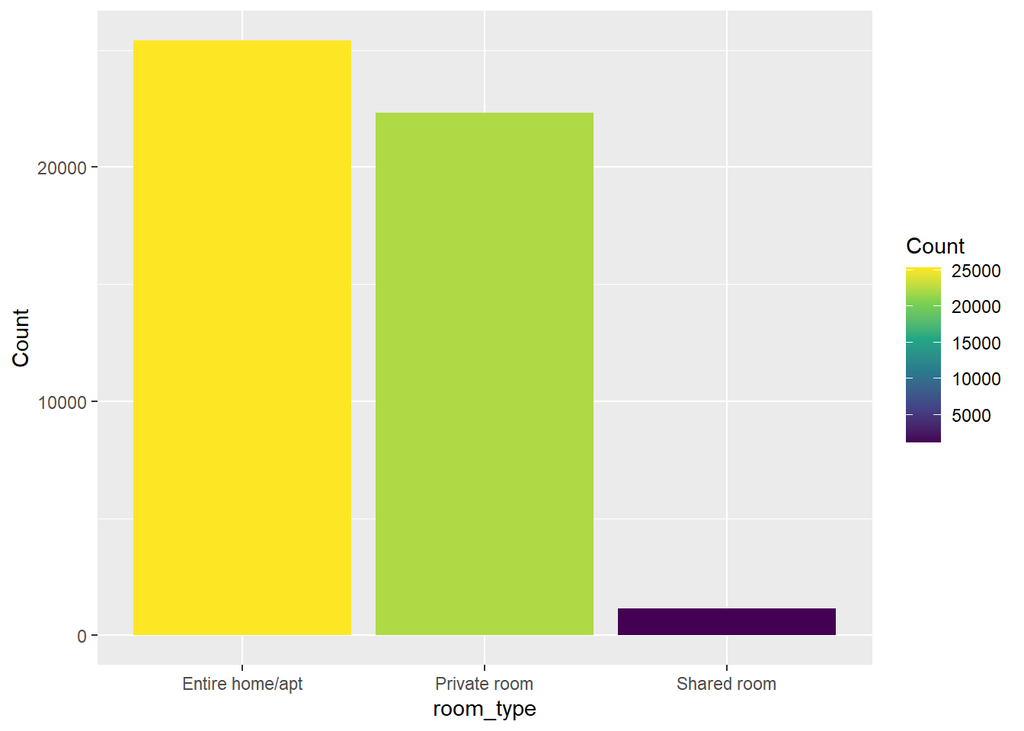

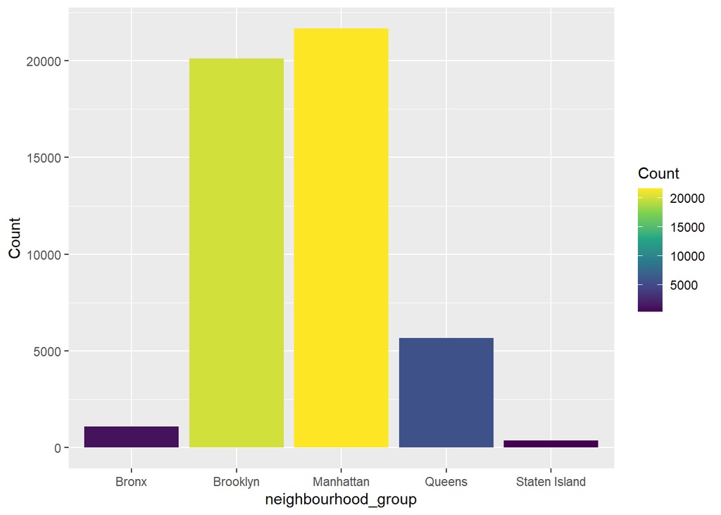

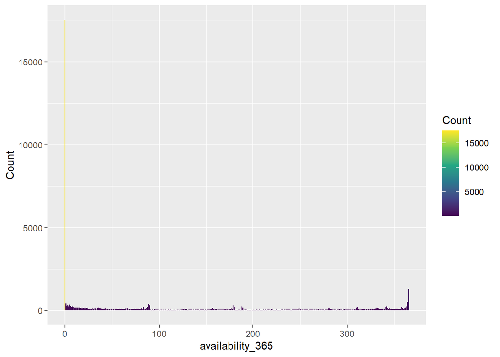

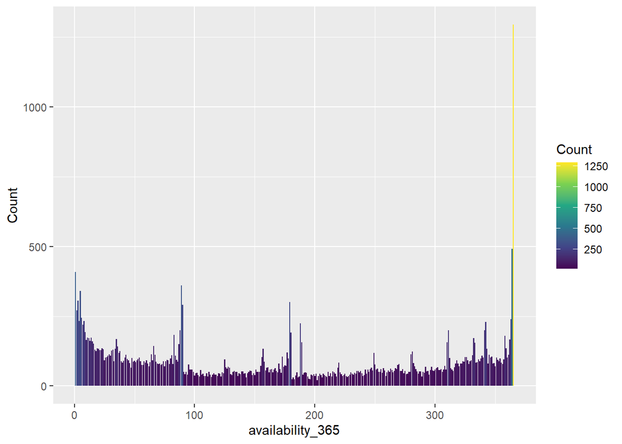

Pri zobrazení histogramov vidíme, že napr. typ izby: celý apartmán je približne rovnako zastúpený ako typ privátna izba. Existuje ale aj malé mnoťstvo ponúk na zdieľanú izbu. Ďalej vidíme počet ponúk v rôznych častiach mesta NY. Keď sme si chceli zobraziť histogram pre počet dní, kedy je apartmán dostupný v roku, zistili sme že veľké množstvo apartmánov nie sú dostupných ani jeden deň v roku. (sú to pravdepodobne nejaké archivované ponuky a podobne). Preto sme si zobrazili aj rozdelenie bez availability=0.

# Chýbajúce hodnoty

```r
# these rows will be dropped where price is 0, because it is not possible to rent a room for free
data %>%
  filter(price == 0) %>%
  select(price, host_name, neighbourhood_group, room_type)
```

```
## # A tibble: 11 × 4
##    price host_name    neighbourhood_group room_type
##    <dbl> <chr>        <chr>               <chr>
##  1     0 Kimberly     Brooklyn            Private room
##  2     0 Anisha       Bronx               Private room
##  3     0 Martial Loft Brooklyn            Private room
##  4     0 Lauren       Brooklyn            Private room
##  5     0 Aymeric      Brooklyn            Entire home/apt
##  6     0 Adeyemi      Brooklyn            Private room
##  7     0 Adeyemi      Brooklyn            Private room
##  8     0 Adeyemi      Brooklyn            Private room
##  9     0 Qiuchi       Manhattan           Entire home/apt
## 10     0 Sergii       Brooklyn            Shared room
## 11     0 Sergii       Brooklyn            Shared room
```

```r
zero_price_count <- nrow(data %>% filter(price == 0))
zero_price_count
```

```
## [1] 11
```

```r
# we can remove rows
data <- data %>% filter(price != 0)

# in dataset there are no rows with price 0 and also with price less than 10
nrow(data %>% filter(price < 10))
```

```
## [1] 0
```

Zistili sme, že v datasete je niekoľko ponúk s nulovou cenou. To v realite nezodpovedá prirodzeným dátam, (keďže nemá zmysel ponúkať apartmány zadarmo, a môže to zmiasť náš model), preto sme sa rozhodli tieto záznamy dropnúť.

```r
# Count empty strings for each column (there are no empty strings)
data %>%
  summarise_all(~sum(str_detect(., "^\\s*$")))
```

```
## # A tibble: 1 × 16
##      id  name host_id host_name neighbourhood_group neighbourhood latitude
##   <int> <int>   <int>     <int>               <int>         <int>    <int>
## 1     0    NA       0        NA                   0             0        0
## # ℹ 9 more variables: longitude <int>, room_type <int>, price <int>,
## #   minimum_nights <int>, number_of_reviews <int>, last_review <int>,
## #   reviews_per_month <int>, calculated_host_listings_count <int>,
## #   availability_365 <int>
```

```r
missing_values_reviews_per_month <- sum(is.na(data$reviews_per_month))
missing_values_reviews_per_month
```

```
## [1] 10051
```

```r
missing_values_last_review <- sum(is.na(data$last_review))
missing_values_last_review
```

```
## [1] 10051
```

Kontrolovali sme aj prázdne texty, ale žiadne sme nenašli.

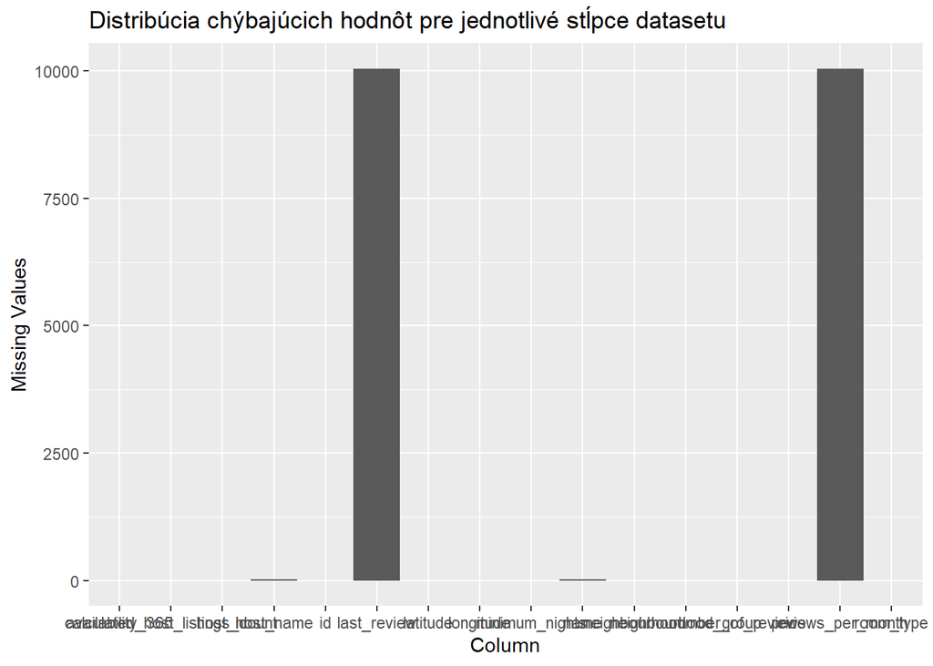

Kontrolovali sme aj ďaľšie chýbajúce hodnoty. Vidíme že pomerne dosť sa ich nachádza aj v stĺpcoch last_reviewd a reviews_per_month. Sú to apartmány, ktoré zatiaľ neboli hodnotené. V niektorých zátnamoch nie je vyplnené meno vlastníka.

# Rozdelenie cien

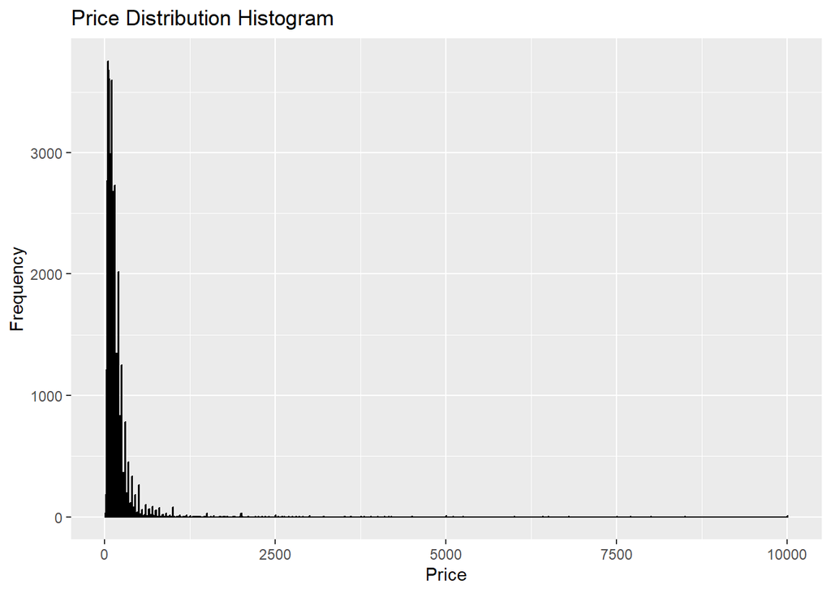

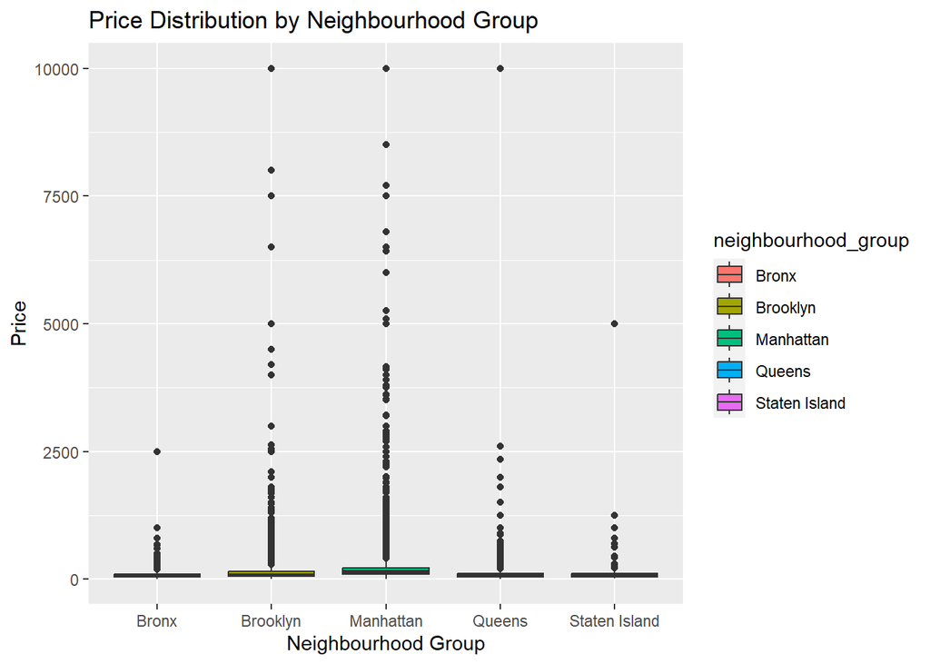

Vidíme, že dataset má v cenách pomerne veľa outlierov v horných hodnotách.

```r
data %>%
  select(host_name, last_review, neighbourhood_group, price) %>%
  group_by(neighbourhood_group) %>%
  summarise(mean_price = mean(price),
            min_price = min(price),
            max_price = max(price),
            number_of_records = n())
```

```
## # A tibble: 5 × 5
##   neighbourhood_group mean_price min_price max_price number_of_records
##   <chr>                    <dbl>     <dbl>     <dbl>             <int>
## 1 Bronx                     87.6        10      2500              1090
## 2 Brooklyn                 124.         10     10000             20095
## 3 Manhattan                197.         10     10000             21660
## 4 Queens                    99.5        10     10000              5666
## 5 Staten Island            115.         13      5000               373
```

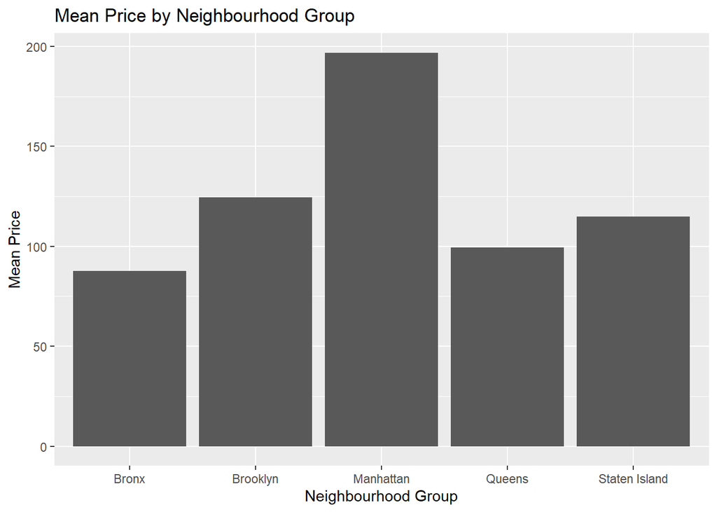

```r
# mean price of housing for each neighbourhood group
data %>%
  select(host_name, last_review, neighbourhood_group, price) %>%
  group_by(neighbourhood_group) %>%
  summarise(mean_price = mean(price),
            min_price = min(price),
            max_price = max(price),
            number_of_records = n()) %>%
  ggplot(aes(x = neighbourhood_group, y = mean_price)) +
  geom_col() +
  labs(title = "Mean Price by Neighbourhood Group", x = "Neighbourhood Group", y = "Mean Price")
```

Najdrahšie apartmány sa nachádzajú v časti Manhattan.

## Pairplot

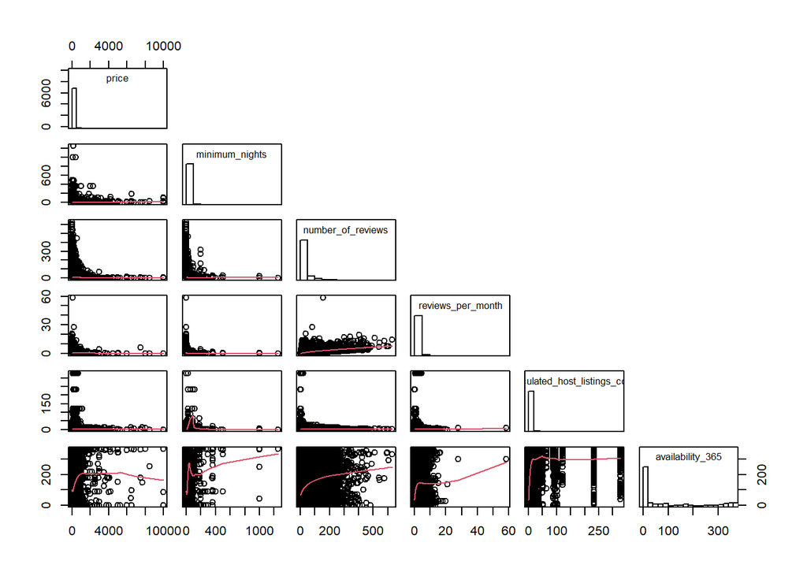

```r
#-----Helper functions-----
panel.cor <- function(x,y, digits=2, prefix="", cex.cor){
  usr <- par("usr")
  on.exit(par(usr))
  par(usr = c(0,1,0,1))
  r <- abs(cor(x,y,use="complete.obs"))
  txt <- format(c(r,0.123456789), digits = digits)[1]
  txt <- paste0(prefix, txt,sep="")
  if(missing(cex.cor)) cex.cor <- 0.8/strwidth(txt)
  text(0.5, 0.5, txt, cex = cex.cor * (1 + r) / 2)
}

panel.hist <- function(x, ...){
  usr <- par("usr")
  on.exit(par(usr))
  par(usr = c(usr[1:2],0,1.5))
  h <- hist(x, plot = FALSE)
  breaks <- h$breaks
  nB <- length(breaks)
  y <- h$counts
  y <- y/max(y)
  rect(breaks[-nB], 0, breaks[-1], y, col="white",...)
}

panel.lm <- function(x,y,col = par("col"), bg = NA, pch = par("pch"),
                     cex = 1, col.smooth = "blue",...){
  points(x,y,pch=pch, col=col(alpha = 0.1), bg=bg, cex=cex)
  abline(stats::lm(x ~ y), col = "steelblue", ...)
}

#-----Pair plot-----
data %$%
  pairs( ~ price + minimum_nights + number_of_reviews + reviews_per_month +
           calculated_host_listings_count + availability_365, # Omit skill_moves from plotting
         upper.panel= NULL,
         diag.panel=panel.hist,
         lower.panel=panel.smooth)
```